# Risk Factor Analysis

## Outcome Variable

**Outcome Variable:** stunted

## Predictor Variables

**Intervention Variable:** single

**Adjustment Set:**

unadjusted

## Stratifying Variables

The analysis was stratified on these variable(s):

- agecat
- studyid
- country

## Data Summary

| agecat | studyid | country | single | stunted | n_cell | n |
| --- | --- | --- | --- | --- | --- | --- |
| Birth | ki0047075b-MAL-ED | BANGLADESH | 0 | 0 | 187 | 231 |
| Birth | ki0047075b-MAL-ED | BANGLADESH | 0 | 1 | 44 | 231 |
| Birth | ki0047075b-MAL-ED | BANGLADESH | 1 | 0 | 0 | 231 |
| Birth | ki0047075b-MAL-ED | BANGLADESH | 1 | 1 | 0 | 231 |
| Birth | ki0047075b-MAL-ED | BRAZIL | 0 | 0 | 51 | 65 |
| Birth | ki0047075b-MAL-ED | BRAZIL | 0 | 1 | 6 | 65 |
| Birth | ki0047075b-MAL-ED | BRAZIL | 1 | 0 | 5 | 65 |
| Birth | ki0047075b-MAL-ED | BRAZIL | 1 | 1 | 3 | 65 |
| Birth | ki0047075b-MAL-ED | INDIA | 0 | 0 | 37 | 47 |
| Birth | ki0047075b-MAL-ED | INDIA | 0 | 1 | 10 | 47 |
| Birth | ki0047075b-MAL-ED | INDIA | 1 | 0 | 0 | 47 |
| Birth | ki0047075b-MAL-ED | INDIA | 1 | 1 | 0 | 47 |
| Birth | ki0047075b-MAL-ED | NEPAL | 0 | 0 | 25 | 27 |
| Birth | ki0047075b-MAL-ED | NEPAL | 0 | 1 | 2 | 27 |
| Birth | ki0047075b-MAL-ED | NEPAL | 1 | 0 | 0 | 27 |
| Birth | ki0047075b-MAL-ED | NEPAL | 1 | 1 | 0 | 27 |
| Birth | ki0047075b-MAL-ED | PERU | 0 | 0 | 187 | 233 |
| Birth | ki0047075b-MAL-ED | PERU | 0 | 1 | 22 | 233 |
| Birth | ki0047075b-MAL-ED | PERU | 1 | 0 | 20 | 233 |
| Birth | ki0047075b-MAL-ED | PERU | 1 | 1 | 4 | 233 |
| Birth | ki0047075b-MAL-ED | SOUTH AFRICA | 0 | 0 | 60 | 123 |
| Birth | ki0047075b-MAL-ED | SOUTH AFRICA | 0 | 1 | 3 | 123 |
| Birth | ki0047075b-MAL-ED | SOUTH AFRICA | 1 | 0 | 53 | 123 |
| Birth | ki0047075b-MAL-ED | SOUTH AFRICA | 1 | 1 | 7 | 123 |
| Birth | ki0047075b-MAL-ED | TANZANIA, UNITED REPUBLIC OF | 0 | 0 | 99 | 125 |
| Birth | ki0047075b-MAL-ED | TANZANIA, UNITED REPUBLIC OF | 0 | 1 | 23 | 125 |
| Birth | ki0047075b-MAL-ED | TANZANIA, UNITED REPUBLIC OF | 1 | 0 | 3 | 125 |
| Birth | ki0047075b-MAL-ED | TANZANIA, UNITED REPUBLIC OF | 1 | 1 | 0 | 125 |
| Birth | ki1119695-PROBIT | BELARUS | 0 | 0 | 13317 | 13890 |
| Birth | ki1119695-PROBIT | BELARUS | 0 | 1 | 31 | 13890 |

[output cut: 138 more lines]

The following strata were considered:

- agecat: 24 months, studyid: ki0047075b-MAL-ED, country: BANGLADESH
- agecat: 24 months, studyid: ki0047075b-MAL-ED, country: BRAZIL
- agecat: 24 months, studyid: ki0047075b-MAL-ED, country: INDIA
- agecat: 24 months, studyid: ki0047075b-MAL-ED, country: NEPAL
- agecat: 24 months, studyid: ki0047075b-MAL-ED, country: PERU
- agecat: 24 months, studyid: ki0047075b-MAL-ED, country: SOUTH AFRICA
- agecat: 24 months, studyid: ki0047075b-MAL-ED, country: TANZANIA, UNITED REPUBLIC OF
- agecat: 24 months, studyid: ki1066203-TanzaniaChild2, country: TANZANIA, UNITED REPUBLIC OF
- agecat: 24 months, studyid: ki1119695-PROBIT, country: BELARUS
- agecat: 24 months, studyid: ki1126311-ZVITAMBO, country: ZIMBABWE
- agecat: 24 months, studyid: ki1135781-COHORTS, country: GUATEMALA
- agecat: 24 months, studyid: ki1135781-COHORTS, country: INDIA
- agecat: 24 months, studyid: ki1135781-COHORTS, country: PHILIPPINES
- agecat: 24 months, studyid: kiGH5241-JiVitA-4, country: BANGLADESH
- agecat: 6 months, studyid: ki0047075b-MAL-ED, country: BANGLADESH
- agecat: 6 months, studyid: ki0047075b-MAL-ED, country: BRAZIL
- agecat: 6 months, studyid: ki0047075b-MAL-ED, country: INDIA
- agecat: 6 months, studyid: ki0047075b-MAL-ED, country: NEPAL
- agecat: 6 months, studyid: ki0047075b-MAL-ED, country: PERU
- agecat: 6 months, studyid: ki0047075b-MAL-ED, country: SOUTH AFRICA
- agecat: 6 months, studyid: ki0047075b-MAL-ED, country: TANZANIA, UNITED REPUBLIC OF
- agecat: 6 months, studyid: ki1066203-TanzaniaChild2, country: TANZANIA, UNITED REPUBLIC OF
- agecat: 6 months, studyid: ki1112895-Guatemala BSC, country: GUATEMALA
- agecat: 6 months, studyid: ki1119695-PROBIT, country: BELARUS
- agecat: 6 months, studyid: ki1126311-ZVITAMBO, country: ZIMBABWE
- agecat: 6 months, studyid: ki1135781-COHORTS, country: GUATEMALA
- agecat: 6 months, studyid: ki1135781-COHORTS, country: INDIA
- agecat: 6 months, studyid: ki1135781-COHORTS, country: PHILIPPINES
- agecat: 6 months, studyid: kiGH5241-JiVitA-4, country: BANGLADESH
- agecat: Birth, studyid: ki0047075b-MAL-ED, country: BANGLADESH
- agecat: Birth, studyid: ki0047075b-MAL-ED, country: BRAZIL
- agecat: Birth, studyid: ki0047075b-MAL-ED, country: INDIA
- agecat: Birth, studyid: ki0047075b-MAL-ED, country: NEPAL
- agecat: Birth, studyid: ki0047075b-MAL-ED, country: PERU
- agecat: Birth, studyid: ki0047075b-MAL-ED, country: SOUTH AFRICA
- agecat: Birth, studyid: ki0047075b-MAL-ED, country: TANZANIA, UNITED REPUBLIC OF
- agecat: Birth, studyid: ki1119695-PROBIT, country: BELARUS
- agecat: Birth, studyid: ki1126311-ZVITAMBO, country: ZIMBABWE
- agecat: Birth, studyid: ki1135781-COHORTS, country: GUATEMALA
- agecat: Birth, studyid: ki1135781-COHORTS, country: INDIA
- agecat: Birth, studyid: ki1135781-COHORTS, country: PHILIPPINES
- agecat: Birth, studyid: kiGH5241-JiVitA-4, country: BANGLADESH

### Dropped Strata

Some strata were dropped due to rare outcomes:

- agecat: Birth, studyid: ki0047075b-MAL-ED, country: BANGLADESH
- agecat: Birth, studyid: ki0047075b-MAL-ED, country: BRAZIL
- agecat: Birth, studyid: ki0047075b-MAL-ED, country: INDIA
- agecat: Birth, studyid: ki0047075b-MAL-ED, country: NEPAL
- agecat: Birth, studyid: ki0047075b-MAL-ED, country: PERU
- agecat: Birth, studyid: ki0047075b-MAL-ED, country: SOUTH AFRICA
- agecat: Birth, studyid: ki0047075b-MAL-ED, country: TANZANIA, UNITED REPUBLIC OF
- agecat: Birth, studyid: ki1119695-PROBIT, country: BELARUS
- agecat: Birth, studyid: ki1135781-COHORTS, country: INDIA
- agecat: Birth, studyid: kiGH5241-JiVitA-4, country: BANGLADESH
- agecat: 6 months, studyid: ki0047075b-MAL-ED, country: BANGLADESH
- agecat: 6 months, studyid: ki0047075b-MAL-ED, country: BRAZIL
- agecat: 6 months, studyid: ki0047075b-MAL-ED, country: INDIA
- agecat: 6 months, studyid: ki0047075b-MAL-ED, country: NEPAL
- agecat: 6 months, studyid: ki0047075b-MAL-ED, country: TANZANIA, UNITED REPUBLIC OF
- agecat: 6 months, studyid: ki1135781-COHORTS, country: INDIA
- agecat: 6 months, studyid: kiGH5241-JiVitA-4, country: BANGLADESH
- agecat: 24 months, studyid: ki0047075b-MAL-ED, country: BANGLADESH
- agecat: 24 months, studyid: ki0047075b-MAL-ED, country: BRAZIL
- agecat: 24 months, studyid: ki0047075b-MAL-ED, country: INDIA
- agecat: 24 months, studyid: ki0047075b-MAL-ED, country: NEPAL
- agecat: 24 months, studyid: ki0047075b-MAL-ED, country: TANZANIA, UNITED REPUBLIC OF
- agecat: 24 months, studyid: ki1066203-TanzaniaChild2, country: TANZANIA, UNITED REPUBLIC OF
- agecat: 24 months, studyid: ki1135781-COHORTS, country: INDIA
- agecat: 24 months, studyid: kiGH5241-JiVitA-4, country: BANGLADESH

## Methods Detail

We’re interested in the causal parameters $E[Y_a]$ for all values of $a \in \mathcal{A}$. These parameters represent the mean outcome if, possibly contrary to fact, we intervened to set all units to have $A=a$. Under the randomization and positivity assumptions, these are identified by the statistical parameters $\psi_a=E_W[E_{Y|A,W}(Y|A=a,W)]$. In addition, we’re interested in the mean of $Y$, $E[Y]$ under no intervention (the observed mean). We will estimate these parameters by using SuperLearner to fit the relevant likelihood factors – $E_{Y|A,W}(Y|A=a,W)$ and $p(A=a|W)$, and then updating our likelihood fit using a joint TMLE.

For unadjusted analyses ($W=\{\}$), initial likelihoods were estimated using Lrnr_glm to estimate the simple $E(Y|A)$ and Lrnr_mean to estimate $p(A)$. For adjusted analyses, a small library containing Lrnr_glmnet, Lrnr_xgboost, and Lrnr_mean was used.

Having estimated these parameters, we will then use the delta method to estimate relative risks and attributable risks relative to a prespecified baseline level of $A$.

# Results Detail

## Results Plots

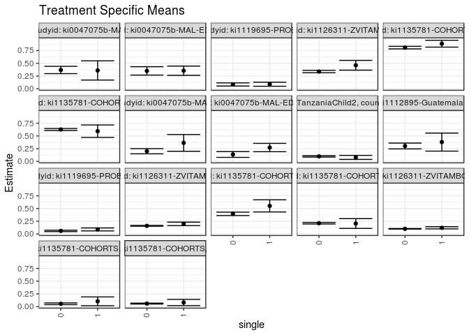

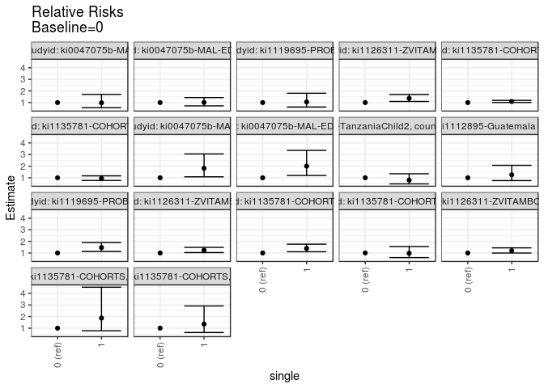

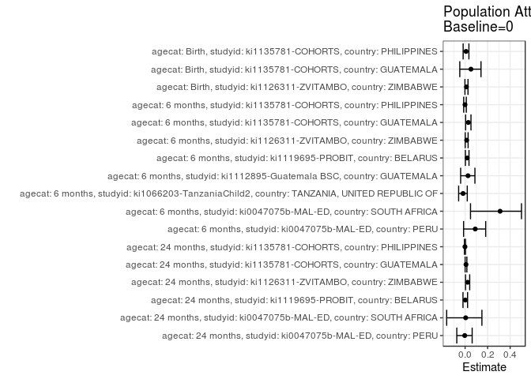

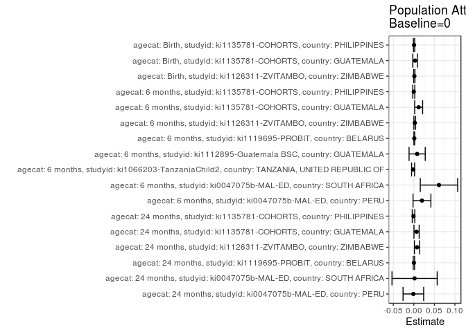

## Results Table

### Parameter: TSM

| agecat | studyid | country | intervention_level | baseline_level | estimate | ci_lower | ci_upper |
| --- | --- | --- | --- | --- | --- | --- | --- |
| Birth | ki1126311-ZVITAMBO | ZIMBABWE | 0 | NA | 0.1021480 | 0.0969303 | 0.1073658 |
| Birth | ki1126311-ZVITAMBO | ZIMBABWE | 1 | NA | 0.1222857 | 0.1005775 | 0.1439939 |
| Birth | ki1135781-COHORTS | GUATEMALA | 0 | NA | 0.0556328 | 0.0388678 | 0.0723978 |
| Birth | ki1135781-COHORTS | GUATEMALA | 1 | NA | 0.1041667 | 0.0176920 | 0.1906413 |
| Birth | ki1135781-COHORTS | PHILIPPINES | 0 | NA | 0.0599455 | 0.0513537 | 0.0685373 |
| Birth | ki1135781-COHORTS | PHILIPPINES | 1 | NA | 0.0810811 | 0.0199126 | 0.1422496 |
| 6 months | ki0047075b-MAL-ED | PERU | 0 | NA | 0.2000000 | 0.1493010 | 0.2506990 |
| 6 months | ki0047075b-MAL-ED | PERU | 1 | NA | 0.3636364 | 0.1992089 | 0.5280638 |
| 6 months | ki0047075b-MAL-ED | SOUTH AFRICA | 0 | NA | 0.1357143 | 0.0788706 | 0.1925580 |
| 6 months | ki0047075b-MAL-ED | SOUTH AFRICA | 1 | NA | 0.2719298 | 0.1900895 | 0.3537701 |
| 6 months | ki1066203-TanzaniaChild2 | TANZANIA, UNITED REPUBLIC OF | 0 | NA | 0.0986376 | 0.0849915 | 0.1122837 |
| 6 months | ki1066203-TanzaniaChild2 | TANZANIA, UNITED REPUBLIC OF | 1 | NA | 0.0786517 | 0.0390957 | 0.1182076 |
| 6 months | ki1112895-Guatemala BSC | GUATEMALA | 0 | NA | 0.3024194 | 0.2451517 | 0.3596870 |
| 6 months | ki1112895-Guatemala BSC | GUATEMALA | 1 | NA | 0.3793103 | 0.2023936 | 0.5562271 |
| 6 months | ki1119695-PROBIT | BELARUS | 0 | NA | 0.0615161 | 0.0478304 | 0.0752018 |
| 6 months | ki1119695-PROBIT | BELARUS | 1 | NA | 0.0902022 | 0.0609997 | 0.1194046 |
| 6 months | ki1126311-ZVITAMBO | ZIMBABWE | 0 | NA | 0.1606154 | 0.1526311 | 0.1685997 |
| 6 months | ki1126311-ZVITAMBO | ZIMBABWE | 1 | NA | 0.1988304 | 0.1642907 | 0.2333701 |
| 6 months | ki1135781-COHORTS | GUATEMALA | 0 | NA | 0.3958838 | 0.3625146 | 0.4292530 |
| 6 months | ki1135781-COHORTS | GUATEMALA | 1 | NA | 0.5522388 | 0.4331034 | 0.6713742 |
| 6 months | ki1135781-COHORTS | PHILIPPINES | 0 | NA | 0.2120399 | 0.1963494 | 0.2277304 |
| 6 months | ki1135781-COHORTS | PHILIPPINES | 1 | NA | 0.2058824 | 0.1097595 | 0.3020052 |
| 24 months | ki0047075b-MAL-ED | PERU | 0 | NA | 0.3693182 | 0.2978389 | 0.4407975 |
| 24 months | ki0047075b-MAL-ED | PERU | 1 | NA | 0.3600000 | 0.1713737 | 0.5486263 |
| 24 months | ki0047075b-MAL-ED | SOUTH AFRICA | 0 | NA | 0.3511450 | 0.2692337 | 0.4330563 |
| 24 months | ki0047075b-MAL-ED | SOUTH AFRICA | 1 | NA | 0.3551402 | 0.2642738 | 0.4460065 |
| 24 months | ki1119695-PROBIT | BELARUS | 0 | NA | 0.0850900 | 0.0543677 | 0.1158123 |
| 24 months | ki1119695-PROBIT | BELARUS | 1 | NA | 0.0896552 | 0.0500934 | 0.1292169 |
| 24 months | ki1126311-ZVITAMBO | ZIMBABWE | 0 | NA | 0.3385519 | 0.3148561 | 0.3622476 |
| 24 months | ki1126311-ZVITAMBO | ZIMBABWE | 1 | NA | 0.4615385 | 0.3656988 | 0.5573782 |
| 24 months | ki1135781-COHORTS | GUATEMALA | 0 | NA | 0.8082340 | 0.7828233 | 0.8336447 |
| 24 months | ki1135781-COHORTS | GUATEMALA | 1 | NA | 0.8850575 | 0.8180027 | 0.9521122 |
| 24 months | ki1135781-COHORTS | PHILIPPINES | 0 | NA | 0.6266440 | 0.6071012 | 0.6461869 |
| 24 months | ki1135781-COHORTS | PHILIPPINES | 1 | NA | 0.5932203 | 0.4707546 | 0.7156861 |

### Parameter: E(Y)

| agecat | studyid | country | intervention_level | baseline_level | estimate | ci_lower | ci_upper |
| --- | --- | --- | --- | --- | --- | --- | --- |
| Birth | ki1126311-ZVITAMBO | ZIMBABWE | NA | NA | 0.1034233 | 0.0983457 | 0.1085009 |
| Birth | ki1135781-COHORTS | GUATEMALA | NA | NA | 0.0586701 | 0.0420278 | 0.0753124 |
| Birth | ki1135781-COHORTS | PHILIPPINES | NA | NA | 0.0604651 | 0.0519489 | 0.0689813 |
| 6 months | ki0047075b-MAL-ED | PERU | NA | NA | 0.2197802 | 0.1705687 | 0.2689917 |
| 6 months | ki0047075b-MAL-ED | SOUTH AFRICA | NA | NA | 0.1968504 | 0.1478551 | 0.2458457 |
| 6 months | ki1066203-TanzaniaChild2 | TANZANIA, UNITED REPUBLIC OF | NA | NA | 0.0968703 | 0.0839461 | 0.1097946 |
| 6 months | ki1112895-Guatemala BSC | GUATEMALA | NA | NA | 0.3104693 | 0.2558835 | 0.3650551 |
| 6 months | ki1119695-PROBIT | BELARUS | NA | NA | 0.0626864 | 0.0488489 | 0.0765238 |
| 6 months | ki1126311-ZVITAMBO | ZIMBABWE | NA | NA | 0.1628849 | 0.1550974 | 0.1706725 |
| 6 months | ki1135781-COHORTS | GUATEMALA | NA | NA | 0.4076148 | 0.3753675 | 0.4398620 |
| 6 months | ki1135781-COHORTS | PHILIPPINES | NA | NA | 0.2118834 | 0.1963977 | 0.2273691 |
| 24 months | ki0047075b-MAL-ED | PERU | NA | NA | 0.3681592 | 0.3013164 | 0.4350020 |
| 24 months | ki0047075b-MAL-ED | SOUTH AFRICA | NA | NA | 0.3529412 | 0.2921001 | 0.4137823 |
| 24 months | ki1119695-PROBIT | BELARUS | NA | NA | 0.0852540 | 0.0554439 | 0.1150642 |
| 24 months | ki1126311-ZVITAMBO | ZIMBABWE | NA | NA | 0.3463653 | 0.3233089 | 0.3694217 |
| 24 months | ki1135781-COHORTS | GUATEMALA | NA | NA | 0.8148515 | 0.7908851 | 0.8388178 |
| 24 months | ki1135781-COHORTS | PHILIPPINES | NA | NA | 0.6258278 | 0.6065280 | 0.6451276 |

### Parameter: RR

| agecat | studyid | country | intervention_level | baseline_level | estimate | ci_lower | ci_upper |
| --- | --- | --- | --- | --- | --- | --- | --- |
| Birth | ki1126311-ZVITAMBO | ZIMBABWE | 0 | 0 | 1.0000000 | 1.0000000 | 1.000000 |
| Birth | ki1126311-ZVITAMBO | ZIMBABWE | 1 | 0 | 1.1971420 | 0.9952252 | 1.440025 |
| Birth | ki1135781-COHORTS | GUATEMALA | 0 | 0 | 1.0000000 | 1.0000000 | 1.000000 |
| Birth | ki1135781-COHORTS | GUATEMALA | 1 | 0 | 1.8723958 | 0.7741873 | 4.528447 |
| Birth | ki1135781-COHORTS | PHILIPPINES | 0 | 0 | 1.0000000 | 1.0000000 | 1.000000 |
| Birth | ki1135781-COHORTS | PHILIPPINES | 1 | 0 | 1.3525799 | 0.6275750 | 2.915145 |
| 6 months | ki0047075b-MAL-ED | PERU | 0 | 0 | 1.0000000 | 1.0000000 | 1.000000 |
| 6 months | ki0047075b-MAL-ED | PERU | 1 | 0 | 1.8181818 | 1.0826943 | 3.053295 |
| 6 months | ki0047075b-MAL-ED | SOUTH AFRICA | 0 | 0 | 1.0000000 | 1.0000000 | 1.000000 |
| 6 months | ki0047075b-MAL-ED | SOUTH AFRICA | 1 | 0 | 2.0036934 | 1.1962950 | 3.356018 |
| 6 months | ki1066203-TanzaniaChild2 | TANZANIA, UNITED REPUBLIC OF | 0 | 0 | 1.0000000 | 1.0000000 | 1.000000 |
| 6 months | ki1066203-TanzaniaChild2 | TANZANIA, UNITED REPUBLIC OF | 1 | 0 | 0.7973803 | 0.4732978 | 1.343373 |
| 6 months | ki1112895-Guatemala BSC | GUATEMALA | 0 | 0 | 1.0000000 | 1.0000000 | 1.000000 |
| 6 months | ki1112895-Guatemala BSC | GUATEMALA | 1 | 0 | 1.2542529 | 0.7581664 | 2.074941 |
| 6 months | ki1119695-PROBIT | BELARUS | 0 | 0 | 1.0000000 | 1.0000000 | 1.000000 |
| 6 months | ki1119695-PROBIT | BELARUS | 1 | 0 | 1.4663188 | 1.1317394 | 1.899811 |
| 6 months | ki1126311-ZVITAMBO | ZIMBABWE | 0 | 0 | 1.0000000 | 1.0000000 | 1.000000 |
| 6 months | ki1126311-ZVITAMBO | ZIMBABWE | 1 | 0 | 1.2379288 | 1.0332950 | 1.483088 |
| 6 months | ki1135781-COHORTS | GUATEMALA | 0 | 0 | 1.0000000 | 1.0000000 | 1.000000 |
| 6 months | ki1135781-COHORTS | GUATEMALA | 1 | 0 | 1.3949518 | 1.1065489 | 1.758522 |
| 6 months | ki1135781-COHORTS | PHILIPPINES | 0 | 0 | 1.0000000 | 1.0000000 | 1.000000 |
| 6 months | ki1135781-COHORTS | PHILIPPINES | 1 | 0 | 0.9709605 | 0.6052100 | 1.557747 |
| 24 months | ki0047075b-MAL-ED | PERU | 0 | 0 | 1.0000000 | 1.0000000 | 1.000000 |
| 24 months | ki0047075b-MAL-ED | PERU | 1 | 0 | 0.9747692 | 0.5575963 | 1.704056 |
| 24 months | ki0047075b-MAL-ED | SOUTH AFRICA | 0 | 0 | 1.0000000 | 1.0000000 | 1.000000 |
| 24 months | ki0047075b-MAL-ED | SOUTH AFRICA | 1 | 0 | 1.0113775 | 0.7153936 | 1.429820 |
| 24 months | ki1119695-PROBIT | BELARUS | 0 | 0 | 1.0000000 | 1.0000000 | 1.000000 |
| 24 months | ki1119695-PROBIT | BELARUS | 1 | 0 | 1.0536514 | 0.6161681 | 1.801751 |
| 24 months | ki1126311-ZVITAMBO | ZIMBABWE | 0 | 0 | 1.0000000 | 1.0000000 | 1.000000 |
| 24 months | ki1126311-ZVITAMBO | ZIMBABWE | 1 | 0 | 1.3632726 | 1.0950029 | 1.697267 |
| 24 months | ki1135781-COHORTS | GUATEMALA | 0 | 0 | 1.0000000 | 1.0000000 | 1.000000 |
| 24 months | ki1135781-COHORTS | GUATEMALA | 1 | 0 | 1.0950510 | 1.0088120 | 1.188662 |
| 24 months | ki1135781-COHORTS | PHILIPPINES | 0 | 0 | 1.0000000 | 1.0000000 | 1.000000 |
| 24 months | ki1135781-COHORTS | PHILIPPINES | 1 | 0 | 0.9466624 | 0.7682828 | 1.166458 |

### Parameter: PAR

| agecat | studyid | country | intervention_level | baseline_level | estimate | ci_lower | ci_upper |
| --- | --- | --- | --- | --- | --- | --- | --- |
| Birth | ki1126311-ZVITAMBO | ZIMBABWE | 0 | NA | 0.0012753 | -0.0001410 | 0.0026915 |
| Birth | ki1135781-COHORTS | GUATEMALA | 0 | NA | 0.0030373 | -0.0025377 | 0.0086123 |
| Birth | ki1135781-COHORTS | PHILIPPINES | 0 | NA | 0.0005196 | -0.0010290 | 0.0020683 |
| 6 months | ki0047075b-MAL-ED | PERU | 0 | NA | 0.0197802 | -0.0019636 | 0.0415241 |
| 6 months | ki0047075b-MAL-ED | SOUTH AFRICA | 0 | NA | 0.0611361 | 0.0156412 | 0.1066310 |
| 6 months | ki1066203-TanzaniaChild2 | TANZANIA, UNITED REPUBLIC OF | 0 | NA | -0.0017673 | -0.0054756 | 0.0019411 |
| 6 months | ki1112895-Guatemala BSC | GUATEMALA | 0 | NA | 0.0080500 | -0.0116153 | 0.0277152 |
| 6 months | ki1119695-PROBIT | BELARUS | 0 | NA | 0.0011703 | 0.0001543 | 0.0021863 |
| 6 months | ki1126311-ZVITAMBO | ZIMBABWE | 0 | NA | 0.0022695 | 0.0001556 | 0.0043835 |
| 6 months | ki1135781-COHORTS | GUATEMALA | 0 | NA | 0.0117310 | 0.0020630 | 0.0213991 |
| 6 months | ki1135781-COHORTS | PHILIPPINES | 0 | NA | -0.0001565 | -0.0026317 | 0.0023187 |
| 24 months | ki0047075b-MAL-ED | PERU | 0 | NA | -0.0011590 | -0.0262516 | 0.0239336 |
| 24 months | ki0047075b-MAL-ED | SOUTH AFRICA | 0 | NA | 0.0017961 | -0.0532043 | 0.0567966 |
| 24 months | ki1119695-PROBIT | BELARUS | 0 | NA | 0.0001641 | -0.0015387 | 0.0018668 |
| 24 months | ki1126311-ZVITAMBO | ZIMBABWE | 0 | NA | 0.0078134 | 0.0013751 | 0.0142518 |
| 24 months | ki1135781-COHORTS | GUATEMALA | 0 | NA | 0.0066175 | 0.0002991 | 0.0129359 |
| 24 months | ki1135781-COHORTS | PHILIPPINES | 0 | NA | -0.0008162 | -0.0039234 | 0.0022910 |

### Parameter: PAF

| agecat | studyid | country | intervention_level | baseline_level | estimate | ci_lower | ci_upper |
| --- | --- | --- | --- | --- | --- | --- | --- |
| Birth | ki1126311-ZVITAMBO | ZIMBABWE | 0 | NA | 0.0123306 | -0.0014480 | 0.0259196 |
| Birth | ki1135781-COHORTS | GUATEMALA | 0 | NA | 0.0517694 | -0.0470659 | 0.1412754 |
| Birth | ki1135781-COHORTS | PHILIPPINES | 0 | NA | 0.0085936 | -0.0173296 | 0.0338562 |
| 6 months | ki0047075b-MAL-ED | PERU | 0 | NA | 0.0900000 | -0.0133927 | 0.1828439 |
| 6 months | ki0047075b-MAL-ED | SOUTH AFRICA | 0 | NA | 0.3105714 | 0.0481228 | 0.5006585 |
| 6 months | ki1066203-TanzaniaChild2 | TANZANIA, UNITED REPUBLIC OF | 0 | NA | -0.0182436 | -0.0571908 | 0.0192689 |
| 6 months | ki1112895-Guatemala BSC | GUATEMALA | 0 | NA | 0.0259284 | -0.0394954 | 0.0872345 |
| 6 months | ki1119695-PROBIT | BELARUS | 0 | NA | 0.0186692 | 0.0025728 | 0.0345058 |
| 6 months | ki1126311-ZVITAMBO | ZIMBABWE | 0 | NA | 0.0139334 | 0.0008801 | 0.0268162 |
| 6 months | ki1135781-COHORTS | GUATEMALA | 0 | NA | 0.0287796 | 0.0047314 | 0.0522468 |
| 6 months | ki1135781-COHORTS | PHILIPPINES | 0 | NA | -0.0007385 | -0.0124887 | 0.0108754 |
| 24 months | ki0047075b-MAL-ED | PERU | 0 | NA | -0.0031480 | -0.0736742 | 0.0627455 |
| 24 months | ki0047075b-MAL-ED | SOUTH AFRICA | 0 | NA | 0.0050891 | -0.1636132 | 0.1493326 |
| 24 months | ki1119695-PROBIT | BELARUS | 0 | NA | 0.0019243 | -0.0186117 | 0.0220462 |
| 24 months | ki1126311-ZVITAMBO | ZIMBABWE | 0 | NA | 0.0225584 | 0.0037899 | 0.0409732 |
| 24 months | ki1135781-COHORTS | GUATEMALA | 0 | NA | 0.0081211 | 0.0003080 | 0.0158730 |
| 24 months | ki1135781-COHORTS | PHILIPPINES | 0 | NA | -0.0013042 | -0.0062817 | 0.0036487 |